# Mapa de Vacinação

Marcos Antônio Alves e Hanna Rodrigues Ferreira

22 junho,2021

Neste trabalho, produzimos um mapa gráfico que fornece uma visualização do atual cenário da pandemia de covid-19 no mundo. Sabemos que os dados são significativamente alterados dia após dia e que novas fases da pandemia se estabelecem de tempos em tempos; no entanto mapas não são adequados para visualizar evolução ao longo do tempo, por isso o objetivo do gráfico é apenas transmitir a informação superficialmente mas de forma mais abrangente possível, de maneira elegante e eficiente.

## Base de dados

Utilizamos os dados do site *ourworldindata* contendo dados sobre testagens, vacinação, novos casos, número de mortos por covid e população de cada país.

- Site:https://ourworldindata.org/covid-vaccinations
- Dados:https://covid.ourworldindata.org/data/owid-covid-data.csv

## Organização da base

```r
library(maps)
library(ggplot2)
library(tidyr)
library(dplyr)
library(viridis)
library(ggthemes)
#theme_set(theme_void())
```

```r
world <- map_data("world")
dado <- read.csv("owid-covid-data.csv")
```

Iremos juntar os dados do mapa com numero de mortes, vacinação e suas respectivas porcentagens.

```r
dado2 <- dado %>% group_by(location) %>% summarise(
  mortes = max(total_deaths, na.rm = TRUE),
  dose1 = max(people_vaccinated - people_fully_vaccinated, na.rm = TRUE),
  dose2 = max(people_fully_vaccinated, na.rm = TRUE),
  vacinadas = max(people_vaccinated, na.rm = TRUE),
  population = max(population))

dado2 <- dado2 %>% mutate(dose1_perc = 100*dose1/population,
                          dose2_perc = 100*dose2/population,
                          vacin_perc = 100*vacinadas/population)


dado2 <- dado2 %>% mutate(mortes = ifelse(!(mortes >= 0), 0, mortes),
      dose1 = ifelse(!(dose1>=0 ), 0, dose1),
      dose2 = ifelse(!(dose2>=0), 0, dose2),
      dose1_perc = ifelse(!(dose1_perc >=0),0,dose1_perc),
      dose2_perc = ifelse(!(dose2_perc >=0),0,dose2_perc))

colnames(dado2)[1] <- "region"



## encontrando conflitos
#d1 <- levels(as.factor(world$region))
#d2 <- levels(as.factor(dado2$region))
#v1 <- d2[!(d2 %in% d1)]
#v2 <- d1[!(d1 %in% d2)]


# O primeiro elementoo é como está em 'world' e o segundo é como está em 'dado'
lista <- c(c("Antigua", "Antigua and Barbuda"),c("Bonaire","Bonaire Sint Eustatius and Saba"),
           c("Democratic Republic of the Congo","Congo"),c("French Guiana","French"),
           c("Republic of Congo","Congo"), c("Trinidad","Trinidad and Tobago"),
           c("Timor-Leste", "Timor"), c("Tobago","Trinidad and Tobago"),
           c("Grenadines", "Saint Vincent and the Grenadines"),c("Saint Vincent","Saint Vincent and the Grenadines"), c("Micronesia" ,"Micronesia (country)" ),
           c("Macedonia","North Macedonia"), c("Czech Republic" ,"Czechia"),
           c("UK","United Kingdom"), c("USA","United States"),
           c("Republic of Congo","Democratic Republic of Congo"),c("Western Sahara","Africa"))

## separando a lista em duas
h1 <- c()
h2 <- c()
for (x in 1:(length(lista)/2)) {
  h1 <- c(h1,lista[2*x -1])
  h2 <- c(h2, lista[2*x])
}

## função para corrigir o nome do país
f <- function(a,b, dado2) {
    dado2 <- dado2 %>% mutate(region = ifelse(as.character(region) == a, b, as.character(region)))
    dado2
}


for (x in 1:length(h1)) {
  dado2 <- f(h2[x],h1[x],dado2)
}
head(dado2)
```

```
## # A tibble: 6 x 9
##   region       mortes   dose1   dose2 vacinadas population dose1_perc dose2_perc
##   <chr>         <dbl>   <dbl>   <dbl>     <dbl>      <dbl>      <dbl>      <dbl>
## 1 Afghanistan    3612  3.93e5  1.77e5    484737   38928341       1.01      0.455
## 2 Western Sah~ 135003  1.91e7  1.15e7  30054491 1340598113       1.42      0.861
## 3 Albania        2453  2.59e5  3.32e5    504257    2877800       9.01     11.5
## 4 Algeria        3579  0       0        2500000   43851043       0         0
## 5 Andorra         127  2.29e4  1.09e4     30535      77265      29.6      14.2
## 6 Angola          836  5.46e5  4.48e5    774926   32866268       1.66      1.36
## # ... with 1 more variable: vacin_perc <dbl>
```

```r
world2 <- left_join(by = "region", x = world, y = dado2)
world2 <- world2 %>% filter(region != "Antarctica" )

world2 <- world2 %>% mutate(dose1 = ifelse(is.na(dose1),0,dose1),
                            dose2 = ifelse(is.na(dose2),0,dose2),
                            dose1_perc = ifelse(is.na(dose1_perc),0,dose1_perc),
                            dose2_perc = ifelse(is.na(dose2_perc),0,dose2_perc),
                            vacin_perc = ifelse(is.na(vacin_perc),0,vacin_perc))

world2 <- world2 %>% mutate(categoria = ifelse(dose2_perc < 0.1, "[0,0.1)",
                                        ifelse(dose2_perc <5,"[0.1,5)",
                                        ifelse(dose2_perc < 15, "[5,15)",
                                        ifelse(dose2_perc < 35, "[15,35)",
                                        ifelse(dose2_perc < 95, "[35,95)", ">95"))))),
                            categoria_vac = ifelse(vacin_perc < 0.1, "[0,0.1)",
                                        ifelse(vacin_perc <5,"[0.1,5)",
                                        ifelse(vacin_perc < 15, "[5,15)",
                                        ifelse(vacin_perc < 35, "[15,35)",
                                        ifelse(vacin_perc < 95, "[35,95)", ">95"))))))
world2 <- world2 %>% mutate(categoria = as.factor(categoria))
```

## Mapas

Para o gráfico principal, optamos por um gráfico mais higiênico possível, uma vez que não queremos desviar a atenção das cores dos países com os gráficos não relacionados aos dados, uma vez que um mapa é muito detalhista. Há outros dois mapas secundários com outras informações.

### Vacinados

Abaixo um mapa com o percentil de vacinados. . A escolha do laranja foi por critério de destaque destaque entre os diferentes tons de cor.

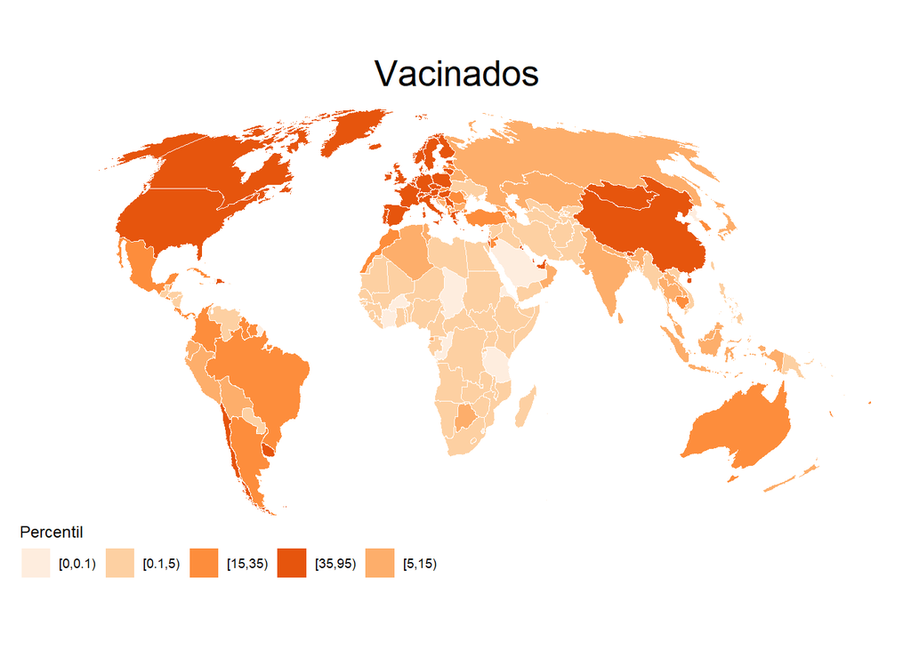

```r
# Gráfico 2: Dados discretos
blue_rev <- RColorBrewer::brewer.pal(n = 6, name = "Oranges")
ggplot(data = world2, mapping = aes(x= long, y = lat, fill = categoria_vac, group = group)) +
  geom_polygon(color = "white", size = 0.3) +
  labs(title = "Vacinados", fill = "Percentil") +
  scale_fill_manual(values = c("[0,0.1)" = blue_rev[1], "[0.1,5)" = blue_rev[2],
                    "[5,15)" = blue_rev[3], "[15,35)" = blue_rev[4], "[35,95)" = blue_rev[5], ">95" = blue_rev[6])) +
  theme_map() +
  guides(fill = guide_legend(nrow = 1)) +
    theme(plot.title = element_text(hjust = 0.5, colour = "Black", size = 20)) +
   coord_map(proj = "mollweide", orientation = c(90,0,0), xlim = c(-130,170), ylim = c(-90,90))
```

### Completamente vacinados

Uma vez feito o mapa, podemos visualizar outros dados da nossa base. Visualizaremos abaixo o percentil de pessoas vacinadas com a segunda dose e mortes. O fundo preto foi pensado para dar destaque ao azul.

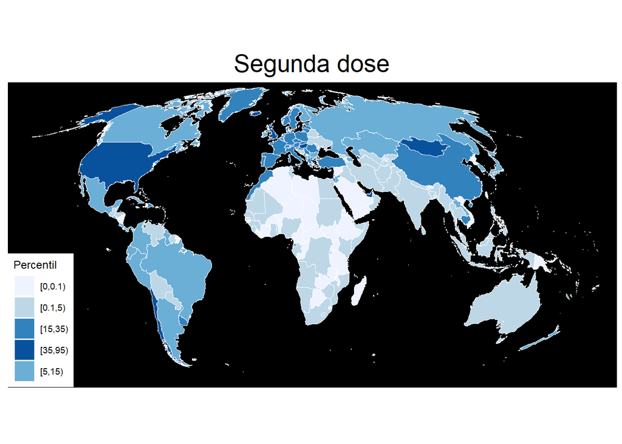

```r
# Gráfico 2: Dados discretos
blue_rev <- RColorBrewer::brewer.pal(n = 5, name = "Blues")
ggplot(data = world2, mapping = aes(x= long, y = lat, fill = categoria, group = group)) +
  geom_polygon(color = "white", size = 0.3) +
  labs(title = "Segunda dose", fill = "Percentil") +
  scale_fill_manual(values = c("[0,0.1)" = blue_rev[1], "[0.1,5)" = blue_rev[2],
                    "[5,15)" = blue_rev[3], "[15,35)" = blue_rev[4], "[35,95)" = blue_rev[5], ">95" = blue_rev[6])) +
  theme_map() +
    theme(
    plot.title = element_text(hjust = 0.5, colour = "Black", size = 20),
    axis.title.x = element_blank(),
    panel.background = element_rect(fill = "#000000"),
    panel.grid = element_blank()) +
   coord_map(proj = "mollweide", orientation = c(90,0,0), xlim = c(-130,170), ylim = c(-60,90))
```

### Mortes por país

Até agora utilizamos gradientes discretos para as cores. Como o número de mortes é mais diverso, optamos por utilizar uma escala contínua para a cor. A escala vai do vermelho ao azul e o meio é justamente a união dessas cores, o roxo.

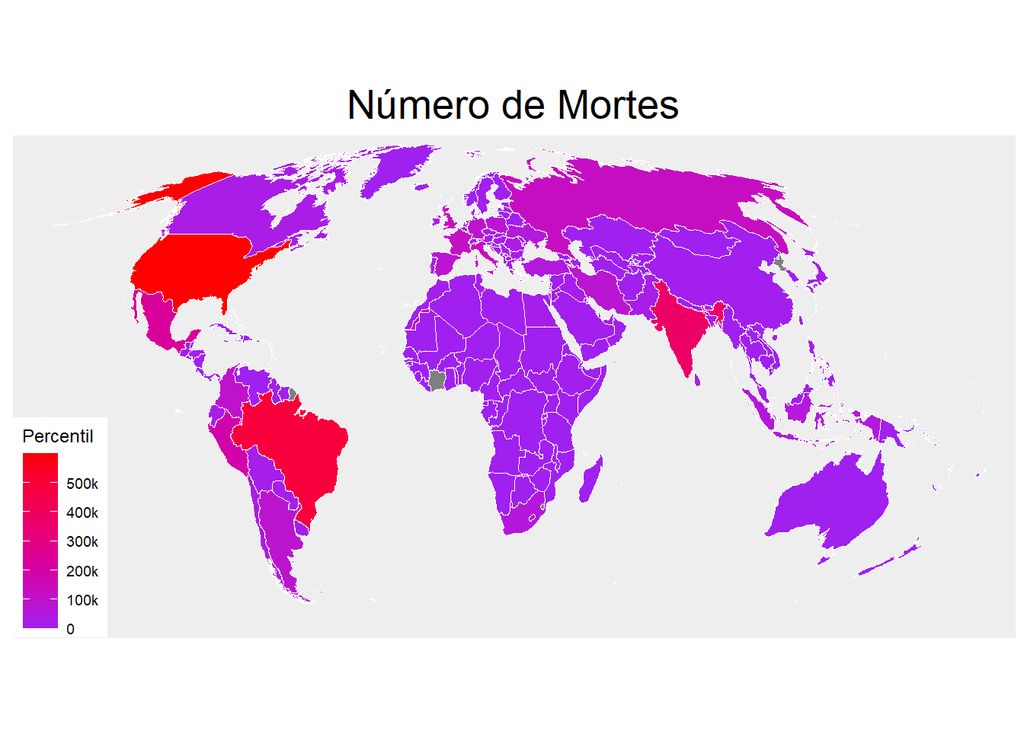

```r
# Grafico 1: Dados contínuos

ggplot(data = world2, mapping = aes(x= long, y = lat, fill = mortes, group = group)) +
  geom_polygon(color = "white", size = 0.3) +
  labs(title = "Número de Mortes", fill = "Percentil") +
  scale_fill_gradient2(low = "#6666FF", midpoint = 15, mid = "purple", high = "red",
                       breaks = c(0,100000,200000,300000,400000,500000),
                       labels = c("0","100k","200k","300k","400k","500k")) +
  theme_map() +
    theme(
    plot.title = element_text(hjust = 0.5, colour = "Black", size = 20),
    axis.title.x = element_blank(),
    panel.background = element_rect(fill = "#EEEEEE", colour = "#EEEEEE"),
    panel.grid = element_blank(),line = element_blank()) +
   coord_map(proj = "mollweide", orientation = c(90,0,0), xlim = c(-130,170), ylim = c(-60,90))
```

Alguns países não fornecem seus dados. Atribuir 0 ou qualquer outro valor a eles não é muito justificável, nesse caso, países em cinza estão com dados faltantes.

Analisando os mapas podemos notar uma associação entre número de vacinados, o que era esperado pois a medida que mais mrtes são confirmadas mais caótica é a situação e o estado toma providências mais rapidamente.